# ps05-rmarkdown-plot

Graydon Perry

2023-02-19

## Load and Check Data

1.) For solving the problems, and answering the questions, create a new rmarkdown document with an appropriate title.

I created the R-Markdown document.

2.) Load data. How many rows/columns do we have?

The *gapminder* dataset has 13055 rows and 25 columns.

3.) Print a small sample of data. Does it look OK?

```
## # A tibble: 5 × 25
##   iso3  name  iso2  region sub-r…¹ inter…²  time total…³ ferti…⁴ lifeE…⁵ child…⁶
##   <chr> <chr> <chr> <chr>  <chr>   <chr>   <dbl>   <dbl>   <dbl>   <dbl>   <dbl>
## 1 AUT   Aust… AT    Europe Wester… <NA>     2005  8.23e6    1.41    79.3     4.9
## 2 KEN   Kenya KE    Africa Sub-Sa… Easter…  1968  1.05e7    8.12    51.4   157.
## 3 STP   Sao … ST    Africa Sub-Sa… Middle…  1974  8.12e4    6.53    57.6    88.1
## 4 AUT   Aust… AT    Europe Wester… <NA>     2007  8.30e6    1.38    80.2     4.6
## 5 PAN   Pana… PA    Ameri… Latin … Centra…  2013  3.84e6    2.58    77.4    18.1
## # … with 14 more variables: youthFemaleLiteracy <dbl>, youthMaleLiteracy <dbl>,
## #   adultLiteracy <dbl>, GDP_PC <dbl>, accessElectricity <dbl>,
## #   agriculturalLand <dbl>, agricultureTractors <dbl>, cerealProduction <dbl>,
## #   fertilizerHa <dbl>, co2 <dbl>, greenhouseGases <dbl>, co2_PC <dbl>,
## #   pm2.5_35 <dbl>, battleDeaths <dbl>, and abbreviated variable names
## #   ¹`sub-region`, ²`intermediate-region`, ³totalPopulation, ⁴fertilityRate,
## #   ⁵lifeExpectancy, ⁶childMortality
```

Yes, this data looks correct to me.

## Descriptive Statistics

1.) How many countries are there in the dataset? Analyze all three: iso3, iso2 and name.

The **iso3** variable shows that there are 253 countries, the **iso2** variable shows that there are 249 countries, and the **name** variables shows that there are 250 countries.

2a.) Find how many names are there for each iso-2 code. Are there any iso-2 codes that correspond to more than one name? What are these countries?

```
## # A tibble: 249 × 2
##    iso2      n
##    <chr> <int>
##  1 <NA>      2
##  2 AD        1
##  3 AE        1
##  4 AF        1
##  5 AG        1
##  6 AI        1
##  7 AL        1
##  8 AM        1
##  9 AO        1
## 10 AQ        1
## # … with 239 more rows
```

```
## # A tibble: 2 × 1
##   n
##   <chr>
## 1 <NA>
## 2 Namibia
```

Based on my analysis, the **NA** variable is the only code that corresponds with multiple names. Those two names are **NA** and **Namibia**.

2b.) Now repeat the same for name and iso3-code. Are there country names that have more than one iso3-code? What are these countries?

```
## # A tibble: 253 × 2
##    iso3      n
##    <chr> <int>
##  1 ABW       1
##  2 AFG       1
##  3 AGO       1
##  4 AIA       1
##  5 ALA       1
##  6 ALB       1
##  7 AND       1
##  8 ARE       1
##  9 ARG       1
## 10 ARM       1
## # … with 243 more rows
```

```
## # A tibble: 250 × 2
##    name               n
##    <chr>          <int>
##  1 <NA>               4
##  2 Afghanistan        1
##  3 Åland Islands      1
##  4 Albania            1
##  5 Algeria            1
##  6 American Samoa     1
##  7 Andorra            1
##  8 Angola             1
##  9 Anguilla           1
## 10 Antarctica         1
## # … with 240 more rows
```

```
## # A tibble: 4 × 1
##   n
##   <chr>
## 1 CHANISL
## 2 GBM
## 3 KOS
## 4 NLD_CURACAO
```

Based on my analysis, the **NA** variable is the only name that corresponds with multiple **is03** codes. Those codes are **CHANSIL**, **GBM**, **KOS**, and **NLD_CURACO**.

3.)

```
## # A tibble: 1 × 1
##    time
##   <dbl>
## 1  1960
```

```
## # A tibble: 1 × 1
##    time
##   <dbl>
## 1  2019
```

The maximum year is **2019** and the minimum year is **1960**.

## CO2 Emissions

1.) How many missing co2 emissions are there for each year? Analyze both missing CO2 and co2_PC. Which years have most missing data?

```
## # A tibble: 60 × 2
##     time     n
##    <dbl> <int>
##  1  2017   217
##  2  2018   217
##  3  2019   217
##  4  1960    60
##  5  1961    60
##  6  1962    58
##  7  1963    57
##  8  1964    51
##  9  1965    51
## 10  1966    51
## # … with 50 more rows
```

2017, 2018, and 2019 respectively have the most missing CO2 emissions, witch 217 each.

2.) Make a plot of total CO2 emissions over time for the U.S, China, and India. Add a few more countries of your choice. Explain what do you see.

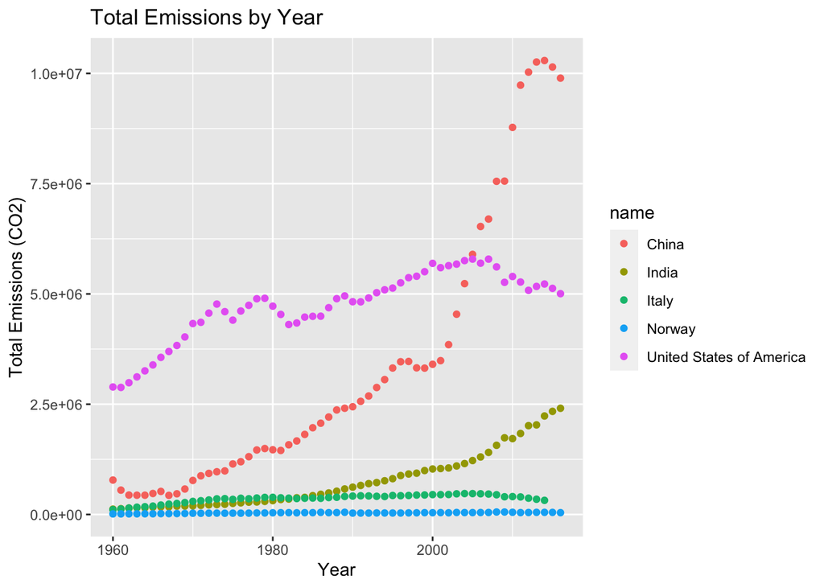

Based on the graph, it appears that **China** and **India** have had increasing CO2 emissions since the year 2000, which could reflect increased industrialization and overall economic activity in that time. In contrast, the **United States** has slightly decreased its emissions since 2000, which could reflect changing attitudes on what energy sources should be used, both for production and other means. As expected, the two European countries have much lower emissions, which most probably indicates their use of alternative energy sources and lack of dependence on fossil fuels.

3.) Now let’s analyze the CO2 emissions per capita (co2_PC ). Make a similar plot of the same countries. What does this figure suggest?

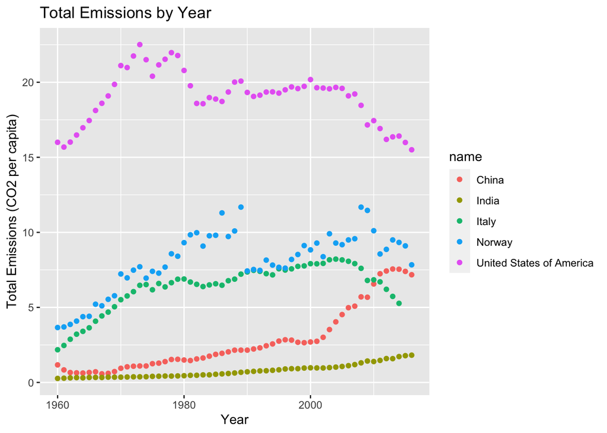

4.) Compute average CO2 emissions per capita across the continents (assume region is the same as continent). Comment what do you see

```
## # A tibble: 5 × 2
##   region       n
##   <chr>    <dbl>
## 1 Africa   0.930
## 2 Americas 6.46
## 3 Asia     6.21
## 4 Europe   7.95
## 5 Oceania  4.39
```

Based on the data in the table, it seems like most of the regions have fairly similar CO2 emissions per capita, except for **Africa**, which has a significantly lower average value than the other regions.

5.) Make a barplot where you show the previous results–average CO2 emissions per capita across continents in 1960 and 2016.

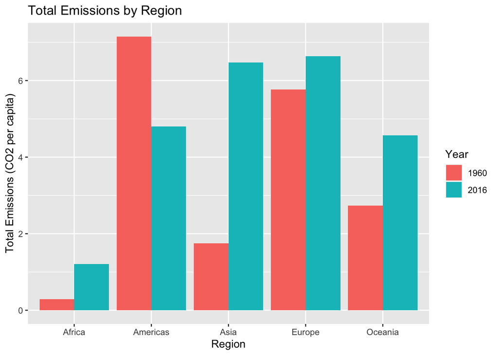

6.) Which countries are the three largest, and three smallest CO2 emitters (in terms of CO2 per capita) in 2019 for each continent? (Assume region is continent).

```
## # A tibble: 15 × 3
## # Groups:   region [5]
##    region   name                                   n
##    <chr>    <chr>                              <dbl>
##  1 Africa   Congo, Democratic Republic of the 0.0256
##  2 Africa   Somalia                           0.0455
##  3 Africa   Burundi                           0.0472
##  4 Americas Haiti                             0.275
##  5 Americas Nicaragua                         0.887
##  6 Americas Honduras                          1.06
##  7 Asia     Afghanistan                       0.245
##  8 Asia     Nepal                             0.334
##  9 Asia     Yemen                             0.390
## 10 Europe   Liechtenstein                     1.36
## 11 Europe   Albania                           1.58
## 12 Europe   Moldova, Republic of              1.83
## 13 Oceania  Solomon Islands                   0.272
## 14 Oceania  Vanuatu                           0.527
## 15 Oceania  Kiribati                          0.587
```

```
## # A tibble: 15 × 3
## # Groups:   region [5]
##    region   name                         n
##    <chr>    <chr>                    <dbl>
##  1 Africa   Seychelles                6.39
##  2 Africa   Libya                     7.79
##  3 Africa   South Africa              8.48
##  4 Americas Canada                   15.1
##  5 Americas United States of America 15.5
##  6 Americas Trinidad and Tobago      31.8
##  7 Asia     Bahrain                  22.2
##  8 Asia     Kuwait                   25.0
##  9 Asia     Qatar                    38.9
## 10 Europe   Faroe Islands            13.1
## 11 Europe   Luxembourg               15.4
## 12 Europe   Gibraltar                18.8
## 13 Oceania  Palau                    12.6
## 14 Oceania  Australia                15.5
## 15 Oceania  New Caledonia            19.3
```

## GDP per capita

1.) Make a scatterplot of GDP per capita versus life expectancy by country, using data for 1960. Make the point size dependent on the country size, and color those according to the continent. Feel free to adjust the plot in other ways to make it better.

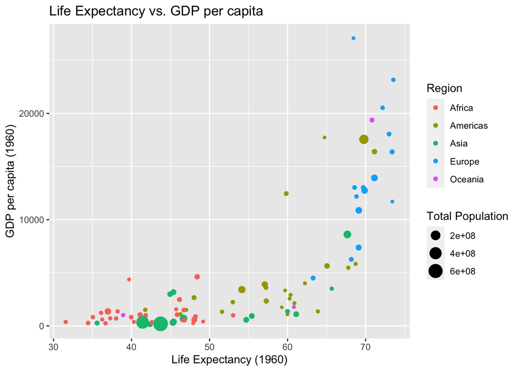

2.) Make a similar plot, but this time use 2019 data only.

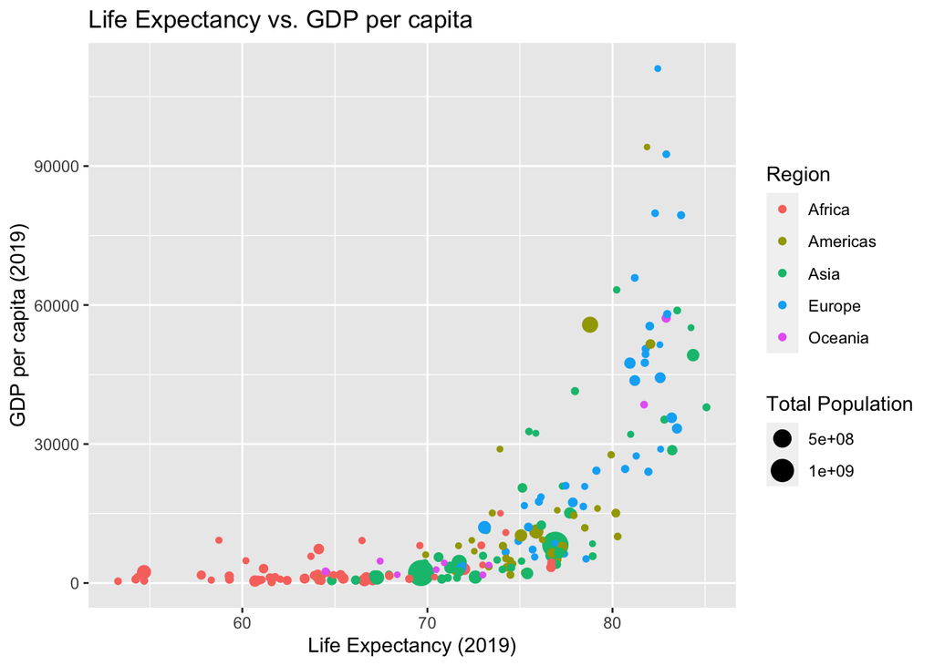

3.) Compare these two plots and comment what do you see. How has world developed through the last 60 years?

4.) Compute the average life expectancy for each continent in 1960 and 2019. Do the results fit with what do you see on the figures?

```
## # A tibble: 10 × 3
##    region    time     n
##    <chr>    <dbl> <dbl>
##  1 Africa    1960  41.5
##  2 Africa    2019  64.1
##  3 Americas  1960  58.6
##  4 Americas  2019  75.8
##  5 Asia      1960  51.6
##  6 Asia      2019  74.6
##  7 Europe    1960  68.3
##  8 Europe    2019  79.4
##  9 Oceania   1960  56.4
## 10 Oceania   2019  73.5
```

These figures do confirm what we see in the plots above, as average life expectancy has increased from 1960 to 2019 fairly significantly.

5.) Compute the average LE growth from 1960-2019 across the continents. Show the results in the order of growth. Explain what do you see.

```
## # A tibble: 5 × 5
## # Groups:   region [5]
##   region    time   avg  prev growth
##   <chr>    <dbl> <dbl> <dbl>  <dbl>
## 1 Asia      2019  74.6  51.6   23.0
## 2 Africa    2019  64.1  41.5   22.6
## 3 Americas  2019  75.8  58.6   17.2
## 4 Oceania   2019  73.5  56.4   17.1
## 5 Europe    2019  79.4  68.3   11.1
```

Based on the information, it seems as though Asia and Africa have seen the most average growth, while Europe has seen by far the least. Oceania and the Americas sit somewhere in the middle.

6.) Show the histogram of GDP per capita for years of 1960 and 2019. Try to put both histograms on the same graph, see how well you can do it!

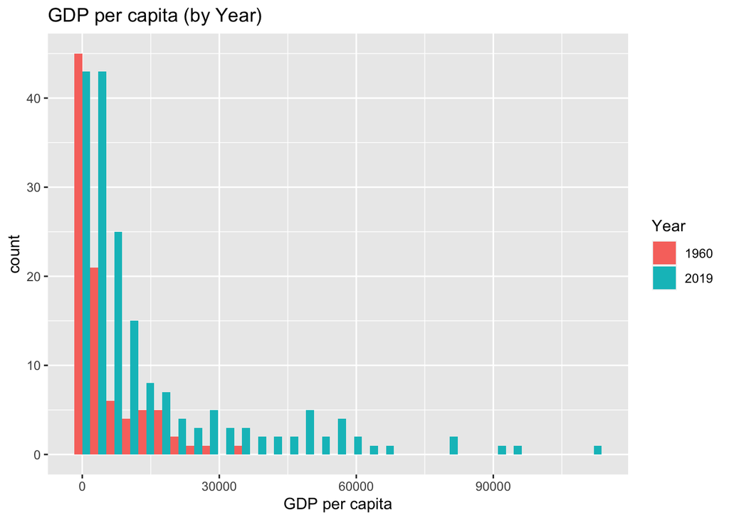

7.) What was the ranking of US in terms of life expectancy in 1960 and in 2019? (When counting from top.)

```
## # A tibble: 2 × 3
## # Groups:   time [2]
##   name                      time  rank
##   <chr>                    <dbl> <dbl>
## 1 United States of America  1960    17
## 2 United States of America  2019    46
```

The United States of America was ranked 17th in 1960 and 46th in 2019.

8.) If you did this correctly, then you noticed that US ranking has been falling quite a bit. But we also have more countries in 2019 – what about the relative rank divided by the corresponding number of countries that have LE data in the corresponding year?

```
## # A tibble: 1 × 3
## # Groups:   time [1]
##   name                      time relative_rank
##   <chr>                    <dbl>         <dbl>
## 1 United States of America  2019         0.235
```

The relative rate for the United States of America in 2019, in terms of life expectancy, was **0.235**.

**Finally**, tell us how many hours did you spend on this PS.

It took me ~5 hours to comlpete this assignment